# Statistical Evaluation : Treatment Comparison Tests Between a Single Factor Variable (2-Level) and a Single Response Variable (Numeric)

John Pauline Pineda

April 26, 2022

# **1. Table of Contents**

This project explores the various methods in comparatively evaluating the numeric response data between two treatment groups in a clinical trial using various helpful packages in **R**. Statistical tests applied in the analysis included the **Student’s T-Test**, **Welch T-Test**, **Wilcoxon Rank-Sum Test** and **Robust Rank-Order Test**. All results were consolidated in a **Summary** presented at the end of the document.  
Although clinical trials are conducted with multiple treatment groups, questions of interest are often expressed as pairwise comparisons among the groups. In a clinical trial involving two forms of intervention groups and a baseline may have as its objective the effectiveness of each intervention, and whether the interventions differ in their effectiveness. The statistical methods applied in this study (mostly contained in the **stats** and **trend** packages) attempt to compare treatment groups in clinical trials given a numeric clinical endpoint.

## 1.1 Sample Data

The **DBP** dataset from the book **Clinical Trial Data Analysis Using R and SAS** was used for this illustrated example.  
Preliminary dataset assessment:  
**[A]** 40 Rows (observations composed of subjects enrolled in the study)  
**[B]** 8 Columns (variables)  
**[B.1]** 1/8 Factor variable = TRT (factor)  
**[B.1.1]** Placebo = placebo drug treatment  
**[B.1.2]** New = new drug treatment  
**[B.2]** 5/8 Response variables = DBP1, DBP2, DBP3, DBP4, DBP5 (numeric)  
**[B.2.1]** DBP1 = diastolic blood pressure baseline measurement made on the 1st month  
**[B.2.2]** DBP2 = diastolic blood pressure measurement made on the 2nd month  
**[B.2.3]** DBP3 = diastolic blood pressure measurement made on the 3rd month  
**[B.2.4]** DBP4 = diastolic blood pressure measurement made on the 4th month  
**[B.2.5]** DBP5 = diastolic blood pressure measurement made on the 5th month  
**[B.3]** 1/8 Covariate variable = Age (numeric)  
**[B.4]** 1/8 Covariate variable = Sex (factor)  
**[B.4.1]** M = male study participant  
**[B.4.2]** F = female study participant

**Code Chunk | Output**

```r
##################################
# Loading R libraries
##################################
library(moments)
library(car)
library(stats)
library(multcomp)
library(effects)
library(psych)
library(ggplot2)
library(dplyr)
library(ggpubr)
library(rstatix)
library(ggfortify)
library(trend)

##################################
# Setting the working directory
##################################
setwd("D:/R_Codes/Markdown/ClinicalTrialDataAnalysis")

##################################
# Reading and creating the complete dataset
##################################
DBP.Complete <- read.csv('DBP.csv',
                na.strings=c("NA","NaN"," ",""),
                stringsAsFactors = T)

##################################
# Performing a general exploration of the dataset
##################################
dim(DBP.Complete)
```

```
## [1] 40  9
```

```r
str(DBP.Complete)
```

```
## 'data.frame':    40 obs. of  9 variables:
##  $ Subject: int  1 2 3 4 5 6 7 8 9 10 ...
##  $ TRT    : Factor w/ 2 levels "A","B": 1 1 1 1 1 1 1 1 1 1 ...
##  $ DBP1   : int  114 116 119 115 116 117 118 120 114 115 ...
##  $ DBP2   : int  115 113 115 113 112 112 111 115 112 113 ...
##  $ DBP3   : int  113 112 113 112 107 113 100 113 113 108 ...
##  $ DBP4   : int  109 103 104 109 104 104 109 102 109 106 ...
##  $ DBP5   : int  105 101 98 101 105 102 99 102 103 97 ...
##  $ Age    : int  43 51 48 42 49 47 50 61 43 51 ...
##  $ Sex    : Factor w/ 2 levels "F","M": 1 2 1 1 2 2 1 2 2 2 ...
```

```r
summary(DBP.Complete)
```

```
##     Subject      TRT         DBP1            DBP2            DBP3
##  Min.   : 1.00   A:20   Min.   :114.0   Min.   :111.0   Min.   :100.0
##  1st Qu.:10.75   B:20   1st Qu.:115.0   1st Qu.:113.0   1st Qu.:112.0
##  Median :20.50          Median :116.5   Median :115.0   Median :113.0
##  Mean   :20.50          Mean   :116.7   Mean   :114.3   Mean   :112.4
##  3rd Qu.:30.25          3rd Qu.:118.0   3rd Qu.:115.0   3rd Qu.:113.0
##  Max.   :40.00          Max.   :121.0   Max.   :119.0   Max.   :118.0
##       DBP4            DBP5            Age        Sex
##  Min.   :102.0   Min.   : 97.0   Min.   :38.00   F:18
##  1st Qu.:106.8   1st Qu.:101.8   1st Qu.:42.00   M:22
##  Median :109.0   Median :106.5   Median :48.00
##  Mean   :109.3   Mean   :106.7   Mean   :47.83
##  3rd Qu.:113.2   3rd Qu.:112.0   3rd Qu.:51.25
##  Max.   :117.0   Max.   :115.0   Max.   :63.00
```

```r
##################################
# Renaming the treatment categories to more verbose labels
##################################
DBP.Complete$TRT <- ifelse(DBP.Complete$TRT=="A","New","Placebo")

##################################
# Setting the levels for the treatment categories
##################################
DBP.Complete$TRT <- factor(DBP.Complete$TRT,
                           levels = c("Placebo","New"))

##################################
# Creating an analysis dataset without the subject information column
##################################
DBP.Analysis <- DBP.Complete[,-1]

##################################
# Creating a response-covariate dataset without the treatment column
##################################
DBP.Response.Covariate <- DBP.Analysis[,-1]

##################################
# Formulating a data type assessment summary
##################################
PDA <- DBP.Response.Covariate
(PDA.Summary <- data.frame(
  Column.Index=c(1:length(names(PDA))),
  Column.Name= names(PDA),
  Column.Type=sapply(PDA, function(x) class(x)),
  row.names=NULL)
)
```

```
##   Column.Index Column.Name Column.Type
## 1            1        DBP1     integer
## 2            2        DBP2     integer
## 3            3        DBP3     integer
## 4            4        DBP4     integer
## 5            5        DBP5     integer
## 6            6         Age     integer
## 7            7         Sex      factor
```

## 1.2 Data Quality Assessment

**[A]** No missing observations noted for any response and covariate variable.  
**[B]** No low variance (Unique.Count.Ratio<0.01 or First.Second.Mode.Ratio>5) noted for any response variable.  
**[C]** No high skewness (Skewness>3 or Skewness<(-3)) noted for any response variable.

**Code Chunk | Output**

```r
##################################
# Restoring the working directory
##################################
setwd("D:/R_Codes/Markdown/ClinicalTrialDataAnalysis")

##################################
# Reusing the response-covariate dataset
##################################
DQA <- DBP.Response.Covariate

##################################
# Formulating a data subset of response variables (numeric)
##################################
DQA.Variables.Response <- DQA[,names(DQA) %in% c("DBP1","DBP2","DBP3","DBP4","DBP5")]

##################################
# Formulating a data subset of covariate variables (numeric)
##################################
DQA.Variables.Covariate.Numeric <- DQA$Age

##################################
# Formulating a data subset of covariate variables (factor)
##################################
DQA.Variables.Covariate.Factor <- DQA$Sex

##################################
# Formulating an overall data quality assessment summary
##################################
(DQA.Summary <- data.frame(
  Column.Index=c(1:length(names(DQA))),
  Column.Name= names(DQA),
  Column.Type=sapply(DQA, function(x) class(x)),
  Row.Count=sapply(DQA, function(x) nrow(DQA)),
  NA.Count=sapply(DQA,function(x)sum(is.na(x))),
  Fill.Rate=sapply(DQA,function(x)format(round((sum(!is.na(x))/nrow(DQA)),3),nsmall=3)),
  row.names=NULL)
)
```

```
##   Column.Index Column.Name Column.Type Row.Count NA.Count Fill.Rate
## 1            1        DBP1     integer        40        0     1.000
## 2            2        DBP2     integer        40        0     1.000
## 3            3        DBP3     integer        40        0     1.000
## 4            4        DBP4     integer        40        0     1.000
## 5            5        DBP5     integer        40        0     1.000
## 6            6         Age     integer        40        0     1.000
## 7            7         Sex      factor        40        0     1.000
```

```r
##################################
# Checking for missing observations
##################################
if ((nrow(DQA.Summary[DQA.Summary$NA.Count>0,]))>0){
  print(paste0("Missing observations noted for ",
               (nrow(DQA.Summary[DQA.Summary$NA.Count>0,])),
               " variable(s) with NA.Count>0 and Fill.Rate<1.0."))
  DQA.Summary[DQA.Summary$NA.Count>0,]
} else {
  print("No missing observations noted.")
}
```

```
## [1] "No missing observations noted."
```

```r
##################################
# Formulating a data quality assessment summary for response variables (numeric)
##################################

if (length(names(DQA.Variables.Response))>0) {

  ##################################
  # Formulating a function to determine the first mode
  ##################################
  FirstModes <- function(x) {
    ux <- unique(na.omit(x))
    tab <- tabulate(match(x, ux))
    ux[tab == max(tab)]
  }

  ##################################
  # Formulating a function to determine the second mode
  ##################################
  SecondModes <- function(x) {
    ux <- unique(na.omit(x))
    tab <- tabulate(match(x, ux))
    fm = ux[tab == max(tab)]
    sm = na.omit(x)[!(na.omit(x) %in% fm)]
    usm <- unique(sm)
    tabsm <- tabulate(match(sm, usm))
    usm[tabsm == max(tabsm)]
  }

  (DQA.Variables.Response.Summary <- data.frame(
  Column.Name= names(DQA.Variables.Response),
  Column.Type=sapply(DQA.Variables.Response, function(x) class(x)),
  Unique.Count=sapply(DQA.Variables.Response, function(x) length(unique(x))),
  Unique.Count.Ratio=sapply(DQA.Variables.Response, function(x) format(round((length(unique(x))/nrow(DQA.Variables.Response)),3), nsmall=3)),
  First.Mode.Value=sapply(DQA.Variables.Response, function(x) format(round((FirstModes(x)[1]),3),nsmall=3)),
  Second.Mode.Value=sapply(DQA.Variables.Response, function(x) format(round((SecondModes(x)[1]),3),nsmall=3)),
  First.Mode.Count=sapply(DQA.Variables.Response, function(x) sum(na.omit(x) == FirstModes(x)[1])),
  Second.Mode.Count=sapply(DQA.Variables.Response, function(x) sum(na.omit(x) == SecondModes(x)[1])),
  First.Second.Mode.Ratio=sapply(DQA.Variables.Response, function(x) format(round((sum(na.omit(x) == FirstModes(x)[1])/sum(na.omit(x) == SecondModes(x)[1])),3), nsmall=3)),
  Minimum=sapply(DQA.Variables.Response, function(x) format(round(min(x,na.rm = TRUE),3), nsmall=3)),
  Mean=sapply(DQA.Variables.Response, function(x) format(round(mean(x,na.rm = TRUE),3), nsmall=3)),
  Median=sapply(DQA.Variables.Response, function(x) format(round(median(x,na.rm = TRUE),3), nsmall=3)),
  Maximum=sapply(DQA.Variables.Response, function(x) format(round(max(x,na.rm = TRUE),3), nsmall=3)),
  Skewness=sapply(DQA.Variables.Response, function(x) format(round(skewness(x,na.rm = TRUE),3), nsmall=3)),
  Kurtosis=sapply(DQA.Variables.Response, function(x) format(round(kurtosis(x,na.rm = TRUE),3), nsmall=3)),
  Percentile25th=sapply(DQA.Variables.Response, function(x) format(round(quantile(x,probs=0.25,na.rm = TRUE),3), nsmall=3)),
  Percentile75th=sapply(DQA.Variables.Response, function(x) format(round(quantile(x,probs=0.75,na.rm = TRUE),3), nsmall=3)),
  row.names=NULL)
  )

}
```

```
##   Column.Name Column.Type Unique.Count Unique.Count.Ratio First.Mode.Value
## 1        DBP1     integer            8              0.200          114.000
## 2        DBP2     integer            8              0.200          115.000
## 3        DBP3     integer           13              0.325          113.000
## 4        DBP4     integer           13              0.325          109.000
## 5        DBP5     integer           16              0.400          115.000
##   Second.Mode.Value First.Mode.Count Second.Mode.Count First.Second.Mode.Ratio
## 1           116.000                9                 8                   1.125
## 2           113.000               17                 6                   2.833
## 3           114.000               19                 4                   4.750
## 4           114.000               12                 8                   1.500
## 5           102.000                6                 5                   1.200
##   Minimum    Mean  Median Maximum Skewness Kurtosis Percentile25th
## 1 114.000 116.650 116.500 121.000    0.244    2.074        115.000
## 2 111.000 114.350 115.000 119.000    0.357    3.139        113.000
## 3 100.000 112.375 113.000 118.000   -1.676    8.305        112.000
## 4 102.000 109.350 109.000 117.000   -0.077    2.114        106.750
## 5  97.000 106.650 106.500 115.000    0.053    1.552        101.750
##   Percentile75th
## 1        118.000
## 2        115.000
## 3        113.000
## 4        113.250
## 5        112.000
```

```r
##################################
# Identifying potential data quality issues for response variables (numeric)
##################################

##################################
# Checking for zero or near-zero variance predictors
##################################
if (length(names(DQA.Variables.Response))==0) {
  print("No numeric predictors noted.")
} else if (nrow(DQA.Variables.Response.Summary[as.numeric(as.character(DQA.Variables.Response.Summary$First.Second.Mode.Ratio))>5,])>0){
  print(paste0("Low variance observed for ",
               (nrow(DQA.Variables.Response.Summary[as.numeric(as.character(DQA.Variables.Response.Summary$First.Second.Mode.Ratio))>5,])),
               " numeric variable(s) with First.Second.Mode.Ratio>5."))
  DQA.Variables.Response.Summary[as.numeric(as.character(DQA.Variables.Response.Summary$First.Second.Mode.Ratio))>5,]
} else {
  print("No low variance numeric predictors due to high first-second mode ratio noted.")
}
```

```
## [1] "No low variance numeric predictors due to high first-second mode ratio noted."
```

```r
if (length(names(DQA.Variables.Response))==0) {
  print("No numeric predictors noted.")
} else if (nrow(DQA.Variables.Response.Summary[as.numeric(as.character(DQA.Variables.Response.Summary$Unique.Count.Ratio))<0.01,])>0){
  print(paste0("Low variance observed for ",
               (nrow(DQA.Variables.Response.Summary[as.numeric(as.character(DQA.Variables.Response.Summary$Unique.Count.Ratio))<0.01,])),
               " numeric variable(s) with Unique.Count.Ratio<0.01."))
  DQA.Variables.Response.Summary[as.numeric(as.character(DQA.Variables.Response.Summary$Unique.Count.Ratio))<0.01,]
} else {
  print("No low variance numeric predictors due to low unique count ratio noted.")
}
```

```
## [1] "No low variance numeric predictors due to low unique count ratio noted."
```

```r
##################################
# Checking for skewed response variables
##################################
if (length(names(DQA.Variables.Response))==0) {
  print("No response variables noted.")
} else if (nrow(DQA.Variables.Response.Summary[as.numeric(as.character(DQA.Variables.Response.Summary$Skewness))>3 |
                                               as.numeric(as.character(DQA.Variables.Response.Summary$Skewness))<(-3),])>0){
  print(paste0("High skewness observed for ",
  (nrow(DQA.Variables.Response.Summary[as.numeric(as.character(DQA.Variables.Response.Summary$Skewness))>3 |
                                               as.numeric(as.character(DQA.Variables.Response.Summary$Skewness))<(-3),])),
  " response variable(s) with Skewness>3 or Skewness<(-3)."))
  DQA.Variables.Response.Summary[as.numeric(as.character(DQA.Variables.Response.Summary$Skewness))>3 |
                                 as.numeric(as.character(DQA.Variables.Response.Summary$Skewness))<(-3),]
} else {
  print("No skewed response variables noted.")
}
```

```
## [1] "No skewed response variables noted."
```

## 1.3 Research Question

Using the **DBP** dataset, treatment comparison tests will be conducted to investigate the following :  
**[A]** Research Question : Do changes in diastolic blood pressure readings measured between the 1st and the 5th months (DBP5-DBP1) differ between treatment groups New and Placebo?  
**[A.1]** Factor variable = TRT  
**[A.1.1]** Placebo = placebo drug treatment  
**[A.1.2]** New = new drug treatment  
**[A.2]** Response variable = DBP5-DBP1

## 1.4 Sample Size and Power Computation

Given that the **DBP** dataset used 20 study subjects for each treatment group TRT=New (new drug) and TRT=Placebo (placebo drug). The following parameters might have been used for determining the appropriate sample size prior to the study :  
**[A. (Mean of Treatment Group)]** Mean change in diastolic blood pressure readings measured between the 1st and the 5th months (DBP5-DBP1) for the treatment group TRT=New (new drug) was hypothesized to be -5.0 (indicating a decrease in diastolic blood pressure).  
**[B. (Mean of Control Group)]** Mean change in diastolic blood pressure readings measured between the 1st and the 5th months (DBP5-DBP1) for the treatment group TRT=Placebo (new drug) was hypothesized to be 0.0 (indicating no change in diastolic blood pressure).  
**[C. (Measurement Standard Deviation)]** Standard deviation of the change in diastolic blood pressure readings measured between the 1st and the 5th months (DBP5-DBP1) was hypothesized to be 5.0.  
**[D. (Effect Size)]** Effect size using Cohen’s D was hypothesized to be 1.0 (large magnitude).  
**[E. (Type I Error = Alpha)]** Type I error (difference between treatment groups is concluded when there is no actual difference) was hypothesized to be 5%.  
**[F. Type II Error= Beta]** Type II error (no difference between treatment groups is concluded when there is an actual difference) was hypothesized to be 20%. Power of the test was hypothesized to be 80%.

**Code Chunk | Output**

```r
##################################
# Determining sample sizes
##################################

##################################
# Defining the range of possible effect sizes
##################################

##################################
# Defining a range of possible hypothesized values for the treatment mean
##################################
mu_Treatment=c(-15,-14,-13,-12,-11,-10,-9,-8,-7,-6,-5,-4,-3)

##################################
# Defining a fixed hypothesized value for the control mean
##################################
mu_Control=0

##################################
# Defining a fixed hypothesized value for the sample size ratio between the treatment and control groups
##################################
kappa=1

##################################
# Defining a fixed hypothesized value for the standard deviation
##################################
sd=5

##################################
# Defining a fixed hypothesized value for the Type I error
##################################
alpha=0.05

##################################
# Defining a range of possible hypothesized values for the Type I error
##################################
beta=c(0.30,0.20,0.10)

##################################
# Computing the range of samples sizes based on different levels type II error
##################################

beta_1=beta[1]
(nB_Beta30=(1+1/kappa)*(sd*(qnorm(1-alpha/2)+qnorm(1-beta_1))/(mu_Treatment-mu_Control))^2)
```

```
##  [1]  1.371570  1.574507  1.826055  2.143079  2.550441  3.086033  3.809918
##  [8]  4.821927  6.298028  8.572315 12.344134 19.287709 34.289261
```

```r
ceiling(nB_Beta30)
```

```
##  [1]  2  2  2  3  3  4  4  5  7  9 13 20 35
```

```r
z_Beta30=(mu_Treatment-mu_Control)/(sd*sqrt((1+1/kappa)/nB_Beta30))
(Power_Beta30=pnorm(z_Beta30-qnorm(1-alpha/2))+pnorm(-z_Beta30-qnorm(1-alpha/2)))
```

```
##  [1] 0.7000044 0.7000044 0.7000044 0.7000044 0.7000044 0.7000044 0.7000044
##  [8] 0.7000044 0.7000044 0.7000044 0.7000044 0.7000044 0.7000044
```

```r
beta_2=beta[2]
(nB_Beta20=(1+1/kappa)*(sd*(qnorm(1-alpha/2)+qnorm(1-beta_2))/(mu_Treatment-mu_Control))^2)
```

```
##  [1]  1.744195  2.002265  2.322154  2.725305  3.243339  3.924440  4.844987
##  [8]  6.131937  8.009061 10.901222 15.697759 24.527749 43.604887
```

```r
ceiling(nB_Beta20)
```

```
##  [1]  2  3  3  3  4  4  5  7  9 11 16 25 44
```

```r
z_Beta20=(mu_Treatment-mu_Control)/(sd*sqrt((1+1/kappa)/nB_Beta20))
(Power_Beta20=pnorm(z_Beta20-qnorm(1-alpha/2))+pnorm(-z_Beta20-qnorm(1-alpha/2)))
```

```
##  [1] 0.800001 0.800001 0.800001 0.800001 0.800001 0.800001 0.800001 0.800001
##  [9] 0.800001 0.800001 0.800001 0.800001 0.800001
```

```r
beta_3=beta[3]
(nB_Beta10=(1+1/kappa)*(sd*(qnorm(1-alpha/2)+qnorm(1-beta_3))/(mu_Treatment-mu_Control))^2)
```

```
##  [1]  2.334983  2.680465  3.108705  3.648411  4.341910  5.253712  6.486064
##  [8]  8.208924 10.721860 14.593643 21.014846 32.835697 58.374573
```

```r
ceiling(nB_Beta10)
```

```
##  [1]  3  3  4  4  5  6  7  9 11 15 22 33 59
```

```r
z_Beta10=(mu_Treatment-mu_Control)/(sd*sqrt((1+1/kappa)/nB_Beta10))
(Power_Beta10=pnorm(z_Beta10-qnorm(1-alpha/2))+pnorm(-z_Beta10-qnorm(1-alpha/2)))
```

```
##  [1] 0.9000001 0.9000001 0.9000001 0.9000001 0.9000001 0.9000001 0.9000001
##  [8] 0.9000001 0.9000001 0.9000001 0.9000001 0.9000001 0.9000001
```

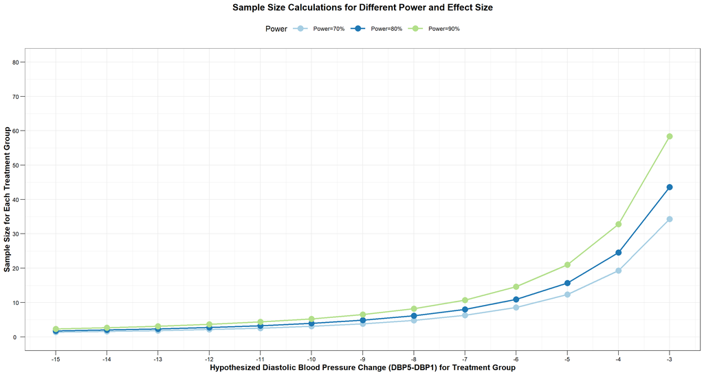

```r
SampleSizePowerCurve <- as.data.frame(cbind(mu_Treatment,nB_Beta30,nB_Beta20,nB_Beta10))
names(SampleSizePowerCurve) <- c("DBP5.DBP1.Difference","Power=70%","Power=80%","Power=90%")

##################################
# Restructuring the data
##################################
SampleSizePowerCurve.Reshaped <- gather(SampleSizePowerCurve,"Power=70%","Power=80%","Power=90%",
                                 key="Power",
                                 value="Sample.Size")

##################################
# Plotting the sample size and power curve
##################################
(DBP5DBP1Difference.SampleSize.LinePlot.ByPower <- ggplot(SampleSizePowerCurve.Reshaped,aes(x=DBP5.DBP1.Difference,
                                                                                            y=Sample.Size,
                                                                                            color=Power)) +
  geom_line(size=1)+
  geom_point(size=4)+
  theme_bw() +
  scale_color_brewer(palette="Paired") +
  scale_x_continuous(name="Hypothesized Diastolic Blood Pressure Change (DBP5-DBP1) for Treatment Group",limits=c(-15,-3),breaks=seq(-15,-3,by=1)) +
  scale_y_continuous(name="Sample Size for Each Treatment Group",limits=c(0,80),breaks=seq(0,80,by=10)) +
  theme(axis.title.x=element_text(color="black",face="bold",size=12),
        legend.position="top",
        legend.key.size = unit(1,"cm"),
        legend.key.height = unit(1,"cm"),
        legend.key.width = unit(1,"cm"),
        legend.title = element_text(size=12),
        legend.text = element_text(size=9),
        text=element_text(size=9),
        axis.text.y=element_text(color="black",hjust=0.25,size=9),
        axis.text.x=element_text(color="black",size=9),
        axis.title.y=element_text(color="black",face="bold",size=12),
        axis.ticks.length=unit(0.25,"cm"),
        plot.title=element_text(color="black",size=14,face="bold",hjust=0.50)) +
  ggtitle("Sample Size Calculations for Different Power and Effect Size"))
```

## 1.5 Data Exploration

Differential boxplot analysis of the response variable DBP5-DBP1 by factor variable TRT showed that :  
**[A]** Higher change in diastolic blood pressure measurements between the 1st and 5th months (DBP5-DBP1) observed for TRT=New (new drug) as compared to TRT=Placebo (placebo drug).  
**[B]** The change in diastolic blood pressure measurements between the 1st and 5th months (DBP5-DBP1) was observed to follow a generally normal distribution for both TRT=New (new drug) and TRT=Placebo (placebo drug).  
**[C]** Minimal outliers observed for both TRT=New (new drug) and TRT=Placebo (placebo drug).

**Code Chunk | Output**

```r
##################################
# Reusing the dataset
##################################
head(DBP.Analysis)
```

```
##   TRT DBP1 DBP2 DBP3 DBP4 DBP5 Age Sex
## 1 New  114  115  113  109  105  43   F
## 2 New  116  113  112  103  101  51   M
## 3 New  119  115  113  104   98  48   F
## 4 New  115  113  112  109  101  42   F
## 5 New  116  112  107  104  105  49   M
## 6 New  117  112  113  104  102  47   M
```

```r
##################################
# Creating the DBP5.DBP1.Difference column
##################################
DBP.Analysis$DBP5.DBP1.Difference <- DBP.Analysis$DBP5-DBP.Analysis$DBP1

##################################
# Printing a subset of the updated dataset
##################################
head(DBP.Analysis)
```

```
##   TRT DBP1 DBP2 DBP3 DBP4 DBP5 Age Sex DBP5.DBP1.Difference
## 1 New  114  115  113  109  105  43   F                   -9
## 2 New  116  113  112  103  101  51   M                  -15
## 3 New  119  115  113  104   98  48   F                  -21
## 4 New  115  113  112  109  101  42   F                  -14
## 5 New  116  112  107  104  105  49   M                  -11
## 6 New  117  112  113  104  102  47   M                  -15
```

```r
##################################
# Determining the max and min values for the DBP5.DBP1.Difference column
##################################
max(DBP.Analysis$DBP5.DBP1.Difference)
```

```
## [1] 1
```

```r
min(DBP.Analysis$DBP5.DBP1.Difference)
```

```
## [1] -21
```

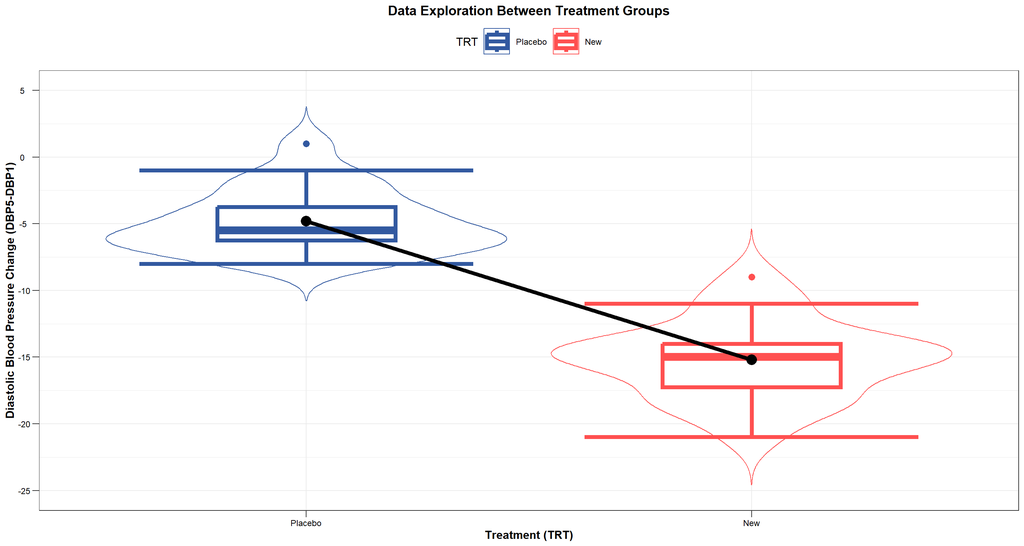

```r
##################################
# Performing exploratory data analysis
##################################
(DBP5DBP1Difference.ViolinBoxplot.ByTreatment <- ggplot(DBP.Analysis,aes(x=TRT,y=DBP5.DBP1.Difference,color=TRT)) +
  geom_violin(scale="width", trim=FALSE) +
  stat_boxplot(geom="errorbar",lwd=2) +
  geom_boxplot(lwd=2, outlier.size=3, width=0.4) +
  theme_bw() +
  scale_fill_manual(values=c("#3259A0","#FF5050")) +
  scale_color_manual(values=c("#3259A0","#FF5050")) +
  scale_x_discrete(name="Treatment (TRT)", limits=c("Placebo","New")) +
  scale_y_continuous(name="Diastolic Blood Pressure Change (DBP5-DBP1)",limits=c(-25,5),breaks=seq(-25,5,by=5)) +
  theme(axis.title.x=element_text(color="black",face="bold",size=12),
        legend.position="top",
        legend.key.size = unit(1,"cm"),
        legend.key.height = unit(1,"cm"),
        legend.key.width = unit(1,"cm"),
        legend.title = element_text(size=12),
        legend.text = element_text(size=9),
        text=element_text(size=9),
        axis.text.y=element_text(color="black",hjust=0.25,size=9),
        axis.text.x=element_text(color="black",size=9),
        axis.title.y=element_text(color="black",face="bold",size=12),
        axis.ticks.length=unit(0.25,"cm"),
        plot.title=element_text(color="black",size=14,face="bold",hjust=0.50)) +
   stat_summary(fun=mean, geom="line",color="black",size=2,aes(group=1)) +
   stat_summary(fun=mean, geom="point",color="black",size=5) +
  ggtitle("Data Exploration Between Treatment Groups"))
```

```r
##################################
# Computing summary statistics
##################################
DBP.Analysis.SummaryStatistics <- DBP.Analysis %>%
  group_by(TRT) %>%
  get_summary_stats(DBP5.DBP1.Difference, show = c("mean", "sd", "median", "q1", "q3", "iqr"))

(as.data.frame(DBP.Analysis.SummaryStatistics))
```

```
##       TRT             variable  n  mean    sd median     q1     q3  iqr
## 1 Placebo DBP5.DBP1.Difference 20  -4.8 2.419   -5.5  -6.25  -3.75 2.50
## 2     New DBP5.DBP1.Difference 20 -15.2 2.966  -15.0 -17.25 -14.00 3.25
```

## 1.6 Evaluation of Important Statistical Assumptions

**Code Chunk | Output**

```r
##################################
# Reusing the dataset
##################################
head(DBP.Analysis)
```

```
##   TRT DBP1 DBP2 DBP3 DBP4 DBP5 Age Sex DBP5.DBP1.Difference
## 1 New  114  115  113  109  105  43   F                   -9
## 2 New  116  113  112  103  101  51   M                  -15
## 3 New  119  115  113  104   98  48   F                  -21
## 4 New  115  113  112  109  101  42   F                  -14
## 5 New  116  112  107  104  105  49   M                  -11
## 6 New  117  112  113  104  102  47   M                  -15
```

```r
##################################
# Identifying extreme outliers
##################################
DBP.Analysis.ExtremeOutliers <- DBP.Analysis %>%
  group_by(TRT) %>%
  identify_outliers(DBP5.DBP1.Difference)

(as.data.frame(DBP.Analysis.ExtremeOutliers))
```

```
##       TRT DBP1 DBP2 DBP3 DBP4 DBP5 Age Sex DBP5.DBP1.Difference is.outlier
## 1 Placebo  114  115  113  114  115  38   M                    1       TRUE
## 2     New  114  115  113  109  105  43   F                   -9       TRUE
##   is.extreme
## 1      FALSE
## 2      FALSE
```

```r
##################################
# Check normality of data distribution
##################################
DBP.Analysis.DistributionalNormality <- DBP.Analysis %>%
  group_by(TRT) %>%
  shapiro_test(DBP5.DBP1.Difference)

(as.data.frame(DBP.Analysis.DistributionalNormality))
```

```
##       TRT             variable statistic         p
## 1 Placebo DBP5.DBP1.Difference 0.9312024 0.1628639
## 2     New DBP5.DBP1.Difference 0.9740958 0.8378696
```

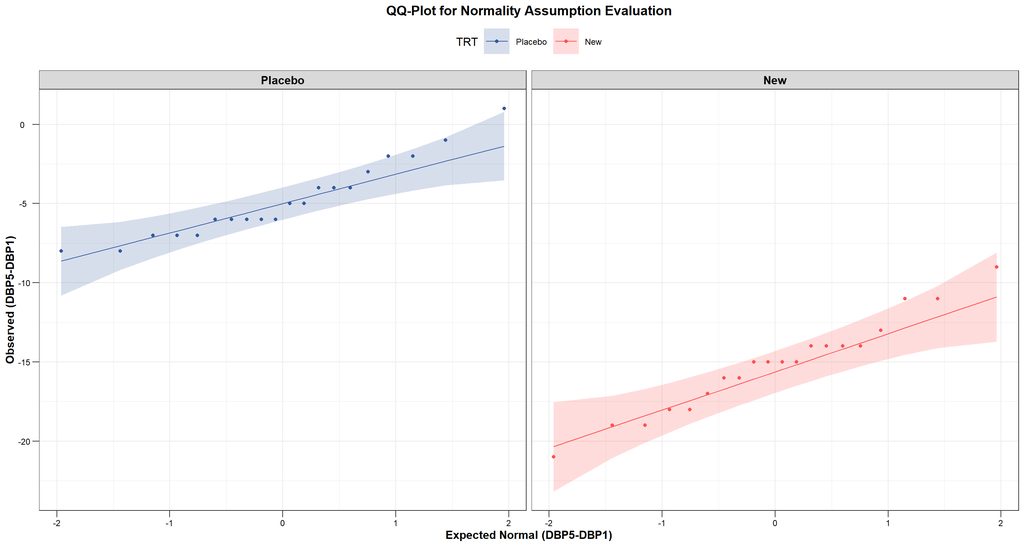

```r
##################################
# Formulating the QQ-Plot
##################################
ggqqplot(DBP.Analysis,x="DBP5.DBP1.Difference",color="TRT",facet.by="TRT") +
  theme_bw() +
  scale_fill_manual(values=c("#3259A0","#FF5050")) +
  scale_color_manual(values=c("#3259A0","#FF5050")) +
  scale_y_continuous(name="Observed (DBP5-DBP1)") +
  scale_x_continuous(name="Expected Normal (DBP5-DBP1)") +
  theme(axis.title.x=element_text(color="black",face="bold",size=12),
        legend.position="top",
        legend.key.size = unit(1,"cm"),
        legend.key.height = unit(1,"cm"),
        legend.key.width = unit(1,"cm"),
        legend.title = element_text(size=12),
        legend.text = element_text(size=9),
        text=element_text(size=9),
        axis.text.y=element_text(color="black",hjust=0.25,size=9),
        axis.text.x=element_text(color="black",size=9),
        axis.title.y=element_text(color="black",face="bold",size=12),
        axis.ticks.length=unit(0.25,"cm"),
        plot.title=element_text(color="black",size=14,face="bold",hjust=0.50),
        strip.text = element_text(color="black",face="bold",size=12)) +
  ggtitle("QQ-Plot for Normality Assumption Evaluation")
```

```r
##################################
# Checking the equality of variances
##################################
DBP.Analysis.VarianceEquality <- DBP.Analysis %>%
  levene_test(DBP5.DBP1.Difference~TRT)

(as.data.frame(DBP.Analysis.VarianceEquality))
```

```
##   df1 df2 statistic        p
## 1   1  38     0.285 0.596552
```

## 1.7 Statistical Tests for Treatment Comparison Between a Single Factor Variable (2-Level) and a Single Response Variable (Numeric)

**[A]** Student’s T-Test can be applied on the dataset considering that no statistical assumptions have been violated.  
**[A.1] Assumption 1: Continuous response variable.** No violation.  
**[A.2] Assumption 2: Two-level factor variable.** No violation.  
**[A.3] Assumption 3: Independent observations.** No violation.  
**[A.4] Assumption 4: Adequate sample size.** No violation.  
**[A.5] Assumption 5: No univariate outliers.** No violation.  
**[A.6] Assumption 6: Univariate normality.** No violation.  
**[A.7] Assumption 7: Homogeneity of variance.** No violation.  
**[B]** For comparison, Welch T-Test will be applied on the dataset which is the appropriate test in cases when the assumption on homogeneity of variance is violated.  
**[C]** For comparison, Wilcoxon Rank-Sum Test will be applied on the dataset which is the appropriate test in cases when the assumption on univariate normality is violated.  
**[D]** For comparison, Robust Rank-Order Test will be applied on the dataset which is the appropriate test in cases when the assumptions on univariate normality and homogeneity of variance are both violated.

### 1.7.1 Student’s T-Test

**Code Chunk | Output**

```r
##################################
# Reusing the dataset
##################################
head(DBP.Analysis)
```

```
##   TRT DBP1 DBP2 DBP3 DBP4 DBP5 Age Sex DBP5.DBP1.Difference
## 1 New  114  115  113  109  105  43   F                   -9
## 2 New  116  113  112  103  101  51   M                  -15
## 3 New  119  115  113  104   98  48   F                  -21
## 4 New  115  113  112  109  101  42   F                  -14
## 5 New  116  112  107  104  105  49   M                  -11
## 6 New  117  112  113  104  102  47   M                  -15
```

```r
##################################
# Conducting Student's T-Test
##################################
DBP.Analysis.StudentTTest <- DBP.Analysis %>%
  t_test(DBP5.DBP1.Difference ~ TRT, var.equal = TRUE, detailed = TRUE) %>%
  add_significance()

(as.data.frame(DBP.Analysis.StudentTTest))
```

```
##   estimate estimate1 estimate2                  .y.  group1 group2 n1 n2
## 1     10.4      -4.8     -15.2 DBP5.DBP1.Difference Placebo    New 20 20
##   statistic        p df conf.low conf.high method alternative p.signif
## 1   12.1504 1.17e-14 38 8.667242  12.13276 T-test   two.sided     ****
```

```r
##################################
# Computing for the effect size
##################################
DBP.Analysis.StudentTTest.EffectSize <- DBP.Analysis %>%
  cohens_d(DBP5.DBP1.Difference ~ TRT, var.equal = TRUE, hedges.correction = TRUE)

(as.data.frame(DBP.Analysis.StudentTTest.EffectSize))
```

```
##                    .y.  group1 group2  effsize n1 n2 magnitude
## 1 DBP5.DBP1.Difference Placebo    New 3.765956 20 20     large
```

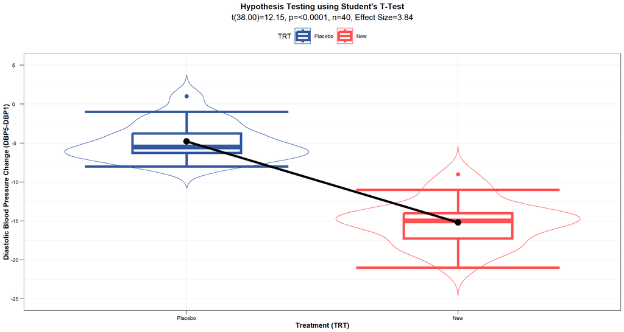

```r
##################################
# Summarizing the hypothesis testing results
##################################

DBP.Analysis.StudentTTest.Statistics <- DBP.Analysis.StudentTTest %>% add_xy_position(x = "group")

(DBP5DBP1Difference.ViolinBoxplot.ByTreatment <- ggplot(DBP.Analysis,aes(x=TRT,y=DBP5.DBP1.Difference,color=TRT)) +
  geom_violin(scale="width", trim=FALSE) +
  stat_boxplot(geom="errorbar",lwd=2) +
  geom_boxplot(lwd=2, outlier.size=3, width=0.4) +
  theme_bw() +
  scale_fill_manual(values=c("#3259A0","#FF5050")) +
  scale_color_manual(values=c("#3259A0","#FF5050")) +
  scale_x_discrete(name="Treatment (TRT)", limits=c("Placebo","New")) +
  scale_y_continuous(name="Diastolic Blood Pressure Change (DBP5-DBP1)",limits=c(-25,5),breaks=seq(-25,5,by=5)) +
  theme(axis.title.x=element_text(color="black",face="bold",size=12),
        legend.position="top",
        legend.key.size = unit(1,"cm"),
        legend.key.height = unit(1,"cm"),
        legend.key.width = unit(1,"cm"),
        legend.title = element_text(size=12),
        legend.text = element_text(size=9),
        text=element_text(size=9),
        axis.text.y=element_text(color="black",hjust=0.25,size=9),
        axis.text.x=element_text(color="black",size=9),
        axis.title.y=element_text(color="black",face="bold",size=12),
        axis.ticks.length=unit(0.25,"cm"),
        plot.title=element_text(color="black",size=14,face="bold",hjust=0.50),
        plot.subtitle = element_text(color="black",size=14,hjust=0.50)) +
   stat_summary(fun=mean, geom="line",color="black",size=2,aes(group=1)) +
   stat_summary(fun=mean, geom="point",color="black",size=5) +
  labs(subtitle = "t(38.00)=12.15, p=<0.0001, n=40, Effect Size=3.84") +
  ggtitle("Hypothesis Testing using Student's T-Test"))
```

### 1.7.2 Welch T-Test

**Code Chunk | Output**

```r
##################################
# Reusing the dataset
##################################
head(DBP.Analysis)
```

```
##   TRT DBP1 DBP2 DBP3 DBP4 DBP5 Age Sex DBP5.DBP1.Difference
## 1 New  114  115  113  109  105  43   F                   -9
## 2 New  116  113  112  103  101  51   M                  -15
## 3 New  119  115  113  104   98  48   F                  -21
## 4 New  115  113  112  109  101  42   F                  -14
## 5 New  116  112  107  104  105  49   M                  -11
## 6 New  117  112  113  104  102  47   M                  -15
```

```r
##################################
# Conducting Welch T-Test
##################################
DBP.Analysis.WelchTTest <- DBP.Analysis %>%
  t_test(DBP5.DBP1.Difference ~ TRT, var.equal = FALSE, detailed = TRUE) %>%
  add_significance()

(as.data.frame(DBP.Analysis.WelchTTest))
```

```
##   estimate estimate1 estimate2                  .y.  group1 group2 n1 n2
## 1     10.4      -4.8     -15.2 DBP5.DBP1.Difference Placebo    New 20 20
##   statistic        p       df conf.low conf.high method alternative p.signif
## 1   12.1504 2.15e-14 36.52227 8.664937  12.13506 T-test   two.sided     ****
```

```r
##################################
# Computing for the effect size
##################################
DBP.Analysis.WelchTTest.EffectSize <- DBP.Analysis %>%
  cohens_d(DBP5.DBP1.Difference ~ TRT, var.equal = FALSE, hedges.correction = TRUE)

(as.data.frame(DBP.Analysis.WelchTTest.EffectSize))
```

```
##                    .y.  group1 group2  effsize n1 n2 magnitude
## 1 DBP5.DBP1.Difference Placebo    New 3.765956 20 20     large
```

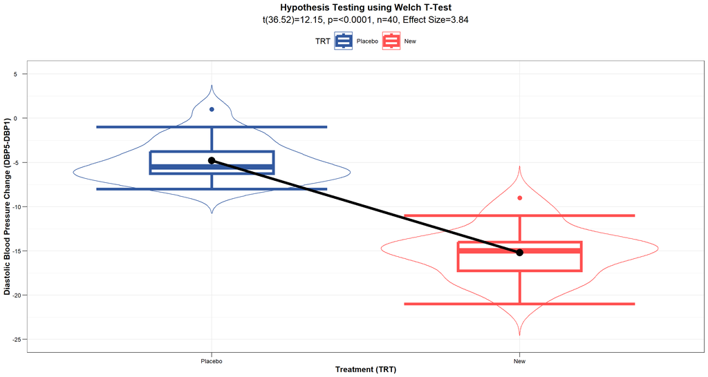

```r
##################################
# Summarizing the hypothesis testing results
##################################

DBP.Analysis.WelchTTest.Statistics <- DBP.Analysis.WelchTTest %>% add_xy_position(x = "group")

(DBP5DBP1Difference.ViolinBoxplot.ByTreatment <- ggplot(DBP.Analysis,aes(x=TRT,y=DBP5.DBP1.Difference,color=TRT)) +
  geom_violin(scale="width", trim=FALSE) +
  stat_boxplot(geom="errorbar",lwd=2) +
  geom_boxplot(lwd=2, outlier.size=3, width=0.4) +
  theme_bw() +
  scale_fill_manual(values=c("#3259A0","#FF5050")) +
  scale_color_manual(values=c("#3259A0","#FF5050")) +
  scale_x_discrete(name="Treatment (TRT)", limits=c("Placebo","New")) +
  scale_y_continuous(name="Diastolic Blood Pressure Change (DBP5-DBP1)",limits=c(-25,5),breaks=seq(-25,5,by=5)) +
  theme(axis.title.x=element_text(color="black",face="bold",size=12),
        legend.position="top",
        legend.key.size = unit(1,"cm"),
        legend.key.height = unit(1,"cm"),
        legend.key.width = unit(1,"cm"),
        legend.title = element_text(size=12),
        legend.text = element_text(size=9),
        text=element_text(size=9),
        axis.text.y=element_text(color="black",hjust=0.25,size=9),
        axis.text.x=element_text(color="black",size=9),
        axis.title.y=element_text(color="black",face="bold",size=12),
        axis.ticks.length=unit(0.25,"cm"),
        plot.title=element_text(color="black",size=14,face="bold",hjust=0.50),
        plot.subtitle = element_text(color="black",size=14,hjust=0.50)) +
   stat_summary(fun=mean, geom="line",color="black",size=2,aes(group=1)) +
   stat_summary(fun=mean, geom="point",color="black",size=5) +
  labs(subtitle = "t(36.52)=12.15, p=<0.0001, n=40, Effect Size=3.84") +
  ggtitle("Hypothesis Testing using Welch T-Test"))
```

### 1.7.3 Wilcoxon Rank-Sum Test

**Code Chunk | Output**

```r
##################################
# Reusing the dataset
##################################
head(DBP.Analysis)
```

```
##   TRT DBP1 DBP2 DBP3 DBP4 DBP5 Age Sex DBP5.DBP1.Difference
## 1 New  114  115  113  109  105  43   F                   -9
## 2 New  116  113  112  103  101  51   M                  -15
## 3 New  119  115  113  104   98  48   F                  -21
## 4 New  115  113  112  109  101  42   F                  -14
## 5 New  116  112  107  104  105  49   M                  -11
## 6 New  117  112  113  104  102  47   M                  -15
```

```r
##################################
# Conducting Welch T-Test
##################################
DBP.Analysis.WilcoxonRankSumTest <- DBP.Analysis %>%
  wilcox_test(DBP5.DBP1.Difference ~ TRT, detailed = TRUE) %>%
  add_significance()

(as.data.frame(DBP.Analysis.WilcoxonRankSumTest))
```

```
##   estimate                  .y.  group1 group2 n1 n2 statistic        p
## 1 10.00008 DBP5.DBP1.Difference Placebo    New 20 20       400 6.29e-08
##   conf.low conf.high   method alternative p.signif
## 1 8.999927  12.00003 Wilcoxon   two.sided     ****
```

```r
##################################
# Computing for the effect size
##################################
DBP.Analysis.WilcoxonRankSumTest.EffectSize <- DBP.Analysis %>%
  wilcox_effsize(DBP5.DBP1.Difference ~ TRT)

(as.data.frame(DBP.Analysis.WilcoxonRankSumTest.EffectSize))
```

```
##                    .y.  group1 group2   effsize n1 n2 magnitude
## 1 DBP5.DBP1.Difference Placebo    New 0.8576142 20 20     large
```

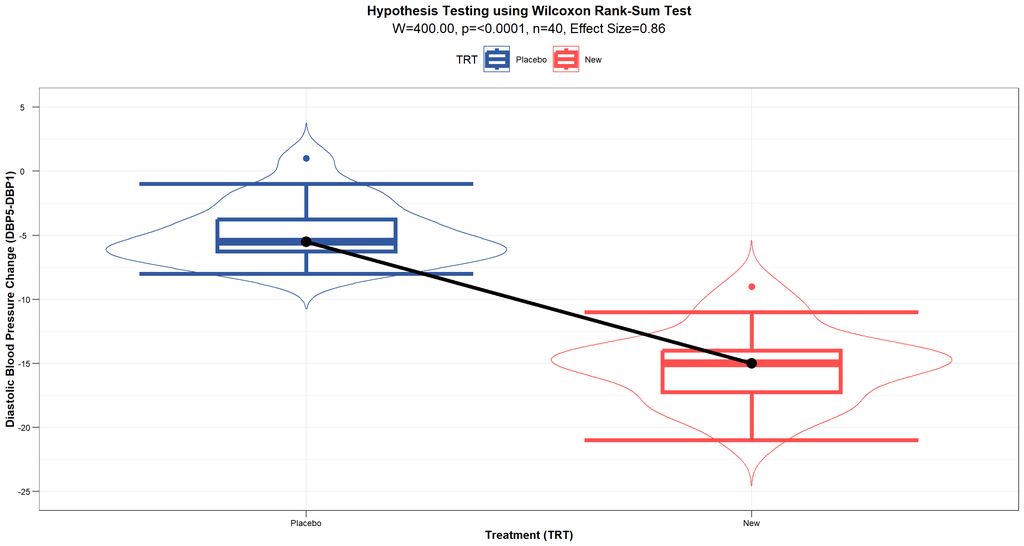

```r
##################################
# Summarizing the hypothesis testing results
##################################

DBP.Analysis.WilcoxonRankSumTest.Statistics <- DBP.Analysis.WilcoxonRankSumTest %>% add_xy_position(x = "group")

(DBP5DBP1Difference.ViolinBoxplot.ByTreatment <- ggplot(DBP.Analysis,aes(x=TRT,y=DBP5.DBP1.Difference,color=TRT)) +
  geom_violin(scale="width", trim=FALSE) +
  stat_boxplot(geom="errorbar",lwd=2) +
  geom_boxplot(lwd=2, outlier.size=3, width=0.4) +
  theme_bw() +
  scale_fill_manual(values=c("#3259A0","#FF5050")) +
  scale_color_manual(values=c("#3259A0","#FF5050")) +
  scale_x_discrete(name="Treatment (TRT)", limits=c("Placebo","New")) +
  scale_y_continuous(name="Diastolic Blood Pressure Change (DBP5-DBP1)",limits=c(-25,5),breaks=seq(-25,5,by=5)) +
  theme(axis.title.x=element_text(color="black",face="bold",size=12),
        legend.position="top",
        legend.key.size = unit(1,"cm"),
        legend.key.height = unit(1,"cm"),
        legend.key.width = unit(1,"cm"),
        legend.title = element_text(size=12),
        legend.text = element_text(size=9),
        text=element_text(size=9),
        axis.text.y=element_text(color="black",hjust=0.25,size=9),
        axis.text.x=element_text(color="black",size=9),
        axis.title.y=element_text(color="black",face="bold",size=12),
        axis.ticks.length=unit(0.25,"cm"),
        plot.title=element_text(color="black",size=14,face="bold",hjust=0.50),
        plot.subtitle = element_text(color="black",size=14,hjust=0.50)) +
   stat_summary(fun=median, geom="line",color="black",size=2,aes(group=1)) +
   stat_summary(fun=median, geom="point",color="black",size=5) +
  labs(subtitle = "W=400.00, p=<0.0001, n=40, Effect Size=0.86") +
  ggtitle("Hypothesis Testing using Wilcoxon Rank-Sum Test"))
```

### 1.7.4 Robust Rank-Order Test

[Robust Rank-Order Test](https://www.semanticscholar.org/paper/Robust-Rank-Procedures-for-the-Behrens-Fisher-Fligner-Policello/74d0191c786a1db3387497b32ec7a7352702b571), also known as the Fligner-Policello Test, is a non-parametric test which is used to determine whether the population medians corresponding to two independent samples are equal. The test assumes that the populations are symmetric about their medians, although the test doesn’t require that the distributions have the same shape nor that their variances be equal. It is a robust rank-order test of treatment effects for populations which assumes neither normality nor equal variances (Behrens-Fisher problem).  
**[A] Study Hypothesis.**  
**[A.1] Null Hypothesis.** There is no difference in the median change in diastolic blood pressure readings measured between the 1st and the 5th months (DBP5-DBP1) between treatment groups TRT=New (new drug) and TRT=Placebo (placebo drug).  
**[A.2] Alternative Hypothesis.** There is a difference in the median change in diastolic blood pressure readings measured between the 1st and the 5th months (DBP5-DBP1) between treatment groups TRT=New (new drug) and TRT=Placebo (placebo drug).  
**[B] Hypothesis Testing Results.** The median change in diastolic blood pressure readings measured between the 1st and the 5th months (DBP5-DBP1) were -15.00 for the treatment group TRT=New (new drug) and -5.50 for the treatment group TRT=Placebo (placebo drug). Robust Rank-Order Test (with relaxed assumptions on both univariate normality and homogeneity of variance) showed that the difference between both treatment groups was statistically significant, z = Inf, p < 0.0001, n=40, effect size=(not determined). There is sufficient statistical evidence to reject the null hypothesis. Therefore, the median change in diastolic blood pressure readings measured between the 1st and the 5th months (DBP5-DBP1) between treatment groups TRT=New (new drug) and TRT=Placebo (placebo drug) were different.

**Code Chunk | Output**

```r
##################################
# Reusing the dataset
##################################
head(DBP.Analysis)
```

```
##   TRT DBP1 DBP2 DBP3 DBP4 DBP5 Age Sex DBP5.DBP1.Difference
## 1 New  114  115  113  109  105  43   F                   -9
## 2 New  116  113  112  103  101  51   M                  -15
## 3 New  119  115  113  104   98  48   F                  -21
## 4 New  115  113  112  109  101  42   F                  -14
## 5 New  116  112  107  104  105  49   M                  -11
## 6 New  117  112  113  104  102  47   M                  -15
```

```r
##################################
# Conducting Welch T-Test
##################################
(DBP.Analysis.RobustRankOrderTest <- rrod.test(DBP5.DBP1.Difference ~ TRT, DBP.Analysis))
```

```
##
##  Robust Rank-Order Distributional Test
##
## data:  DBP5.DBP1.Difference by TRT
## z = Inf, p-value < 2.2e-16
## alternative hypothesis: true location shift is not equal to 0
```

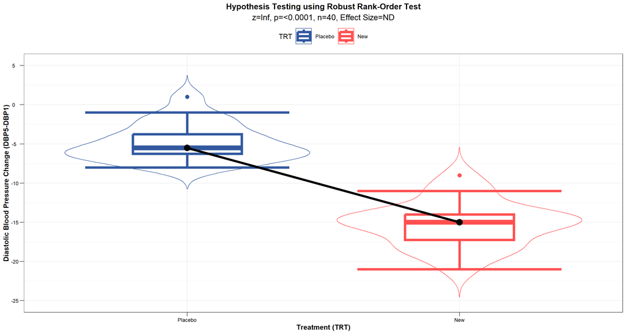

```r
##################################
# Summarizing the hypothesis testing results
##################################

(DBP5DBP1Difference.ViolinBoxplot.ByTreatment <- ggplot(DBP.Analysis,aes(x=TRT,y=DBP5.DBP1.Difference,color=TRT)) +
  geom_violin(scale="width", trim=FALSE) +
  stat_boxplot(geom="errorbar",lwd=2) +
  geom_boxplot(lwd=2, outlier.size=3, width=0.4) +
  theme_bw() +
  scale_fill_manual(values=c("#3259A0","#FF5050")) +
  scale_color_manual(values=c("#3259A0","#FF5050")) +
  scale_x_discrete(name="Treatment (TRT)", limits=c("Placebo","New")) +
  scale_y_continuous(name="Diastolic Blood Pressure Change (DBP5-DBP1)",limits=c(-25,5),breaks=seq(-25,5,by=5)) +
  theme(axis.title.x=element_text(color="black",face="bold",size=12),
        legend.position="top",
        legend.key.size = unit(1,"cm"),
        legend.key.height = unit(1,"cm"),
        legend.key.width = unit(1,"cm"),
        legend.title = element_text(size=12),
        legend.text = element_text(size=9),
        text=element_text(size=9),
        axis.text.y=element_text(color="black",hjust=0.25,size=9),
        axis.text.x=element_text(color="black",size=9),
        axis.title.y=element_text(color="black",face="bold",size=12),
        axis.ticks.length=unit(0.25,"cm"),
        plot.title=element_text(color="black",size=14,face="bold",hjust=0.50),
        plot.subtitle = element_text(color="black",size=14,hjust=0.50)) +
   stat_summary(fun=median, geom="line",color="black",size=2,aes(group=1)) +
   stat_summary(fun=median, geom="point",color="black",size=5) +
  labs(subtitle = "z=Inf, p=<0.0001, n=40, Effect Size=ND") +
  ggtitle("Hypothesis Testing using Robust Rank-Order Test"))
```

# **2. Summary**

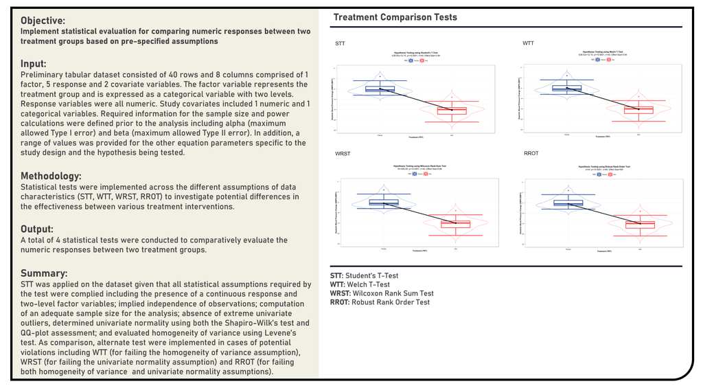

# **3. References**

**[Book]** [Clinical Trial Data Analysis Using R and SAS](https://www.routledge.com/Clinical-Trial-Data-Analysis-Using-R-and-SAS/Chen-Peace-Zhang/p/book/9780367736217) by Ding-Geng Chen, Karl Peace and Pinggao Zhang  
**[Book]** [Nonparametric Statistics for the Behavioral Sciences](https://www.semanticscholar.org/paper/Nonparametric-Statistics-for-the-Behavioral-David-Siegel/53b9b242f8cb2007e8e3dd9db5cd11b88fa6c4a7) by Sidney Siegel and John Castellan  
**[Book]** [Handbook of Parametric and Nonparametric Statistical Procedures](https://www.taylorfrancis.com/books/mono/10.1201/9781420036268/handbook-parametric-nonparametric-statistical-procedures-david-sheskin) by David Sheskin  
**[R Package]** [rstatix](https://mran.microsoft.com/web/packages/rstatix/index.html) by Alboukadel Kassambara  
**[R Package]** [car](https://cran.r-project.org/web/packages/car/vignettes/embedding.pdf) by John Fox and Sanford Weisberg  
**[R Package]** [effects](https://cran.r-project.org/web/packages/effects/vignettes/methods-supported-by-effects.pdf) by John Fox and Sanford Weisberg  
**[R Package]** [multcomp](https://cran.r-project.org/web/packages/multcomp/vignettes/generalsiminf.pdf) by Torsten Hothorn, Frank Bretz and Peter Westfall  
**[R Package]** [psych](http://personality-project.org/r/overview.pdf) by William Revelle  
**[R Package]** [bootstrap](https://cran.r-project.org/web/packages/bootstrap/bootstrap.pdf) by Robert Tibshirani  
**[R Package]** [moments](https://cran.r-project.org/web/packages/moments/index.html) by Lukasz Komsta and Frederick Novomestky  
**[R Package]** [dplyr](https://cran.r-project.org/web/packages/dplyr/index.html) by Hadley Wickham  
**[R Package]** [ggplot2](https://cran.r-project.org/web/packages/ggplot2/) by Hadley Wickham  
**[R Package]** [ggpubr](https://cran.r-project.org/web/packages/ggpubr/index.html) by Alboukadel Kassambara  
**[R Package]** [ggfortify](https://cran.r-project.org/web/packages/ggfortify/index.html) by Yuan Tang  
**[R Package]** [trend](https://cran.r-project.org/web/packages/trend/index.html) by Thorsten Pohlert  
**[Article]** [Comparing Means of Two Groups in R](https://www.datanovia.com/en/courses/comparing-means-of-two-groups-in-r/) by Alboukadel Kassambara  
**[Article]** [T-Test Essentials: Definition, Formula and Calculation](https://www.datanovia.com/en/lessons/types-of-t-test/) by Alboukadel Kassambara  
**[Article]** [Comparing Means in R](http://sthda.com/english/wiki/comparing-means-in-r) by Alboukadel Kassambara  
**[Article]** [T-Test (Student’s T-Test) – Understanding the Math and How It Works](https://www.machinelearningplus.com/statistics/t-test-students-understanding-the-math-and-how-it-works/) by Selva Prabhakaran  
**[Article]** [Student’s T Distribution](https://www.real-statistics.com/students-t-distribution/) by Charles Zaiontz  
**[Article]** [Welch’s T-Test: When to Use It + Examples](https://www.statology.org/welchs-t-test/) by Statology Team  
**[Article]** [Two Sample T-Test: Unequal Variances](https://real-statistics.com/students-t-distribution/two-sample-t-test-uequal-variances/) by Charles Zaiontz  
**[Article]** [The Unequal Variance Welch T-Test](https://www.graphpad.com/guides/prism/latest/statistics/stat_the_unequal_variance_welch_t_t.htm) by GraphPad Team  
**[Article]** [How to Determine Equal or Unequal Variance in T-Tests](https://www.statology.org/determine-equal-or-unequal-variance/) by Statology Team  
**[Article]** [The Wilcoxon Rank Sum Test](https://data.library.virginia.edu/the-wilcoxon-rank-sum-test/) by University of Virginia Library  
**[Article]** [Mann Whitney U Test (Wilcoxon Rank Sum Test)](https://sphweb.bumc.bu.edu/otlt/MPH-Modules/BS/BS704_Nonparametric/BS704_Nonparametric4.html) by Boston University School of Public Health  
**[Article]** [Interpreting Results: Mann-Whitney Test](https://www.graphpad.com/guides/prism/latest/statistics/how_the_mann-whitney_test_works.htm) by GraphPad Team  
**[Article]** [Fligner-Policello Test](https://real-statistics.com/non-parametric-tests/fligner-policello-test/) by Charles Zaiontz  
**[Article]** [Fligner-Policello Test](https://support.sas.com/documentation/cdl/en/statug/65328/HTML/default/viewer.htm#statug_npar1way_details20.htm) by SAS Team  
**[Publication]** [The Probable Error of a Mean](https://www.semanticscholar.org/paper/THE-PROBABLE-ERROR-OF-A-MEAN-Student/01cd1182a27f503a5935f9f2deb17dc1c8d65856) by William Gossett (Biometrika)  
**[Publication]** [The Generalisation of Student’s Problems When Several Different Population Variances are Involved](https://www.semanticscholar.org/paper/The-generalisation-of-student%27s-problems-when-are-Welch/ea0190e9062c66e170a26a2861323010b1e65ec3) by Bernard Welch (Biometrika)  
**[Publication]** [Individual Comparisons by Ranking Methods](https://www.semanticscholar.org/paper/Individual-Comparisons-by-Ranking-Methods-Wilcoxon/59d823fc9877f8d448ac4c2d90e38051026e3201) by Frank Wilcoxon (Biometrika)  
**[Publication]** [On a Test of Whether one of Two Random Variables is Stochastically Larger than the Other](https://www.semanticscholar.org/paper/On-a-Test-of-Whether-one-of-Two-Random-Variables-is-Mann-Whitney/60f788264e6278374be9dabd8e2a644cc65129b6) by Henry Mann and Donald Whitney (Annals of Mathematical Statistics)  
**[Publication]** [Robust Rank Procedures for the Behrens-Fisher Problem](https://www.semanticscholar.org/paper/Robust-Rank-Procedures-for-the-Behrens-Fisher-Fligner-Policello/74d0191c786a1db3387497b32ec7a7352702b571) by Michael Fligner and George Policello (Journal of the American Statistical Association)  
**[Publication]** [Fermat, Schubert, Einstein, and Behrens-Fisher: The Probable Difference Between Two Means With Different Variances](https://www.semanticscholar.org/paper/Fermat%2C-Schubert%2C-Einstein%2C-and-Behrens-Fisher%3A-The-Sawilowsky/edc96140dc5d7c28159c04272c22bc7783421a8a) by Shlomo Sawilowsky (Journal of Modern Applied Statistical Methods)